# はじめてのデータ・サイエンス

Last Updated: 2023-06-06

## はじめに

## データサイエンス？

データから情報を得るときには、大体次のような手順をとります。

1. 準備 Setup
2. データを取得 Import data
3. データ構造の確認 View data
4. 必要に応じて整形 Transform data
5. 視覚化 Visualize data
6. データを理解 Understand data
7. レポートなどにまとめる Communicate data

[figure not shown]

問いをもちデータを取得し、視覚化などを通して、データを理解し、さらに問いを深めるサイクルが、データサイエンスの核だと思います。

## R のパッケージを活用

### 準備 Setup

世界銀行（World Bank）の、世界開発指標（WDI: World Development Indicators）の一つの、GDP（Gross Domestic Product 国内総生産）のデータから始めます。GDP にも何種類かの尺度がありますが、次のものを見てみます。

- NY.GDP.MKTP.CD: GDP (current US$)

NY.GDP.MKTP.CD は、データコードと言われるもので、世界開発指標（WDI）には、一つづつ決まっています。

[World Development Indicators](https://datatopics.worldbank.org/world-development-indicators/) のサイトの下にある、Data Themes（テーマ）からテーマを選択し、下にスクロールすると、Code をみることができます。ちなみに、ここで利用する NY.GDP.MKTP.CD: GDP (current US$) は、テーマの Economy（経済）の、一番上にあります。

経済用語の英語はよく知らないという方は、ブラウザー（Edge, Google Chrome, Safari など）の翻訳機能を使うのも良いでしょう。ただ、そのページの対話型の機能（interactive function）を利用するときは、翻訳機能をOFF にする必要がある場合もありますので、注意してください。

エラーメッセージを調べるときなどに、英語のほうが情報がたくさん得られますから、言語を、英語に変更しておきます。

R には、WDI のデータを取得する R のツール（パッケージ）`WDI` がありますから、それを使います。また、データを取り扱うための基本的なツール（パッケージ）`tidyverse` を使いますので、次のコードで、これらを読み込みます。

```r
Sys.setenv(LANG = "en")
library(tidyverse)
library(WDI)
```

### データ取得 Import data

データを取得します。少し時間がかかります。取得したデータに、`df_gdp` などと、わかりやすい名前をつけます。`df` は `data frame` の略で、R で標準的なデータの形式です。

```r
df_gdp <- WDI(country = "all",
              indicator = c(gdp = "NY.GDP.MKTP.CD"),
              extra = TRUE)
```

このコードで、全ての国の GDP を取得できます。GDP の値は、`NY.GDP.MKTP.CD` という名前の列にありますが、覚えやすいように、gdp という名前に変更しておきます。`extra = TRUE` とすることによって、それぞれの国についての情報などが追加されます。

### データ構造の確認

最初の数行だけを見るには、`head(df_dgp)` とします。

```r
head(df_gdp)
```

```
##       country iso2c iso3c year        gdp status lastupdated     region capital
## 1 Afghanistan    AF   AFG 1963  751111191         2023-05-10 South Asia   Kabul
## 2 Afghanistan    AF   AFG 1962  546666678         2023-05-10 South Asia   Kabul
## 3 Afghanistan    AF   AFG 1961  548888896         2023-05-10 South Asia   Kabul
## 4 Afghanistan    AF   AFG 1960  537777811         2023-05-10 South Asia   Kabul
## 5 Afghanistan    AF   AFG 2003 4539500884         2023-05-10 South Asia   Kabul
## 6 Afghanistan    AF   AFG 2002 3854235264         2023-05-10 South Asia   Kabul
##   longitude latitude     income lending
## 1   69.1761  34.5228 Low income     IDA
## 2   69.1761  34.5228 Low income     IDA
## 3   69.1761  34.5228 Low income     IDA
## 4   69.1761  34.5228 Low income     IDA
## 5   69.1761  34.5228 Low income     IDA
## 6   69.1761  34.5228 Low income     IDA
```

データの構造を見るときには、`str(df_gdp)` もよく使われます。今度は、列が縦に並んで表示されます。

```r
str(df_gdp)
```

```
## 'data.frame':    16758 obs. of  13 variables:
##  $ country    : chr  "Afghanistan" "Afghanistan" "Afghanistan" "Afghanistan" ...
##  $ iso2c      : chr  "AF" "AF" "AF" "AF" ...
##  $ iso3c      : chr  "AFG" "AFG" "AFG" "AFG" ...
##  $ year       : int  1963 1962 1961 1960 2003 2002 2001 2000 1995 1994 ...
##  $ gdp        : num  7.51e+08 5.47e+08 5.49e+08 5.38e+08 4.54e+09 ...
##   ..- attr(*, "label")= chr "GDP (current US$)"
##  $ status     : chr  "" "" "" "" ...
##  $ lastupdated: chr  "2023-05-10" "2023-05-10" "2023-05-10" "2023-05-10" ...
##  $ region     : chr  "South Asia" "South Asia" "South Asia" "South Asia" ...
##  $ capital    : chr  "Kabul" "Kabul" "Kabul" "Kabul" ...
##  $ longitude  : chr  "69.1761" "69.1761" "69.1761" "69.1761" ...
##  $ latitude   : chr  "34.5228" "34.5228" "34.5228" "34.5228" ...
##  $ income     : chr  "Low income" "Low income" "Low income" "Low income" ...
##  $ lending    : chr  "IDA" "IDA" "IDA" "IDA" ...
```

概要 (`summary(df_gdp)`) からもある程度わかります。

```r
summary(df_gdp)
```

```
##    country             iso2c              iso3c                year
##  Length:16758       Length:16758       Length:16758       Min.   :1960
##  Class :character   Class :character   Class :character   1st Qu.:1975
##  Mode  :character   Mode  :character   Mode  :character   Median :1991
##                                                           Mean   :1991
##                                                           3rd Qu.:2007
##                                                           Max.   :2022
##
##       gdp               status          lastupdated           region
##  Min.   :8.824e+06   Length:16758       Length:16758       Length:16758
##  1st Qu.:2.442e+09   Class :character   Class :character   Class :character
##  Median :1.784e+10   Mode  :character   Mode  :character   Mode  :character
##  Mean   :1.161e+12
##  3rd Qu.:2.156e+11
##  Max.   :9.653e+13
##  NA's   :3602
##    capital           longitude           latitude            income
##  Length:16758       Length:16758       Length:16758       Length:16758
##  Class :character   Class :character   Class :character   Class :character
##  Mode  :character   Mode  :character   Mode  :character   Mode  :character
##
##
##
##
##    lending
##  Length:16758
##  Class :character
##  Mode  :character
##
##
##
##
```

国のリストをみてみましょう。とても長いリストの中には、地域名も含まれています。

```r
df_gdp %>% distinct(country) %>% pull()
```

```
##   [1] "Afghanistan"
##   [2] "Africa Eastern and Southern"
##   [3] "Africa Western and Central"
##   [4] "Albania"
##   [5] "Algeria"
##   [6] "American Samoa"
##   [7] "Andorra"
##   [8] "Angola"
##   [9] "Antigua and Barbuda"
##  [10] "Arab World"
##  [11] "Argentina"
##  [12] "Armenia"
##  [13] "Aruba"
##  [14] "Australia"
##  [15] "Austria"
```

[output cut: 251 more lines]

今回は下のように、`%>%`（パイプと呼びます） で繋げてコードを書きました。

```
df_gdp %>% distinct(country) %>% pull()
```

最初は、データ、その中の、異なる国を選択して、書き出してくださいというものです。

これは、

```
pull(distinct(df_gdp, country))
```

と同じです。どんどん、かっこの中に入れ子になって複雑になるので、一つ一つのステップを、順に書いたものが、最初のものになります。

```
df_gdp %>% head()
df_gdp %>% str()
```

なども可能です。かっこの中に最初に入るものが直前のもの、ここでは、データになっています。

### 必要に応じて整形 Transform data

変数が多いので、日本の部分だけ `filter` を使って選択します。country が Japan と一致する場合のみを選択するときは、`==` を使います。数値ではないので、引用符をつけます。半角を使ってください。

```r
df_gdp %>% filter(country == "Japan")
```

```
##    country iso2c iso3c year          gdp status lastupdated              region
## 1    Japan    JP   JPN 2022           NA         2023-05-10 East Asia & Pacific
## 2    Japan    JP   JPN 2021 4.940878e+12         2023-05-10 East Asia & Pacific
## 3    Japan    JP   JPN 2020 5.040108e+12         2023-05-10 East Asia & Pacific
## 4    Japan    JP   JPN 2019 5.123318e+12         2023-05-10 East Asia & Pacific
## 5    Japan    JP   JPN 2018 5.037835e+12         2023-05-10 East Asia & Pacific
## 6    Japan    JP   JPN 2017 4.930837e+12         2023-05-10 East Asia & Pacific
## 7    Japan    JP   JPN 2016 5.003678e+12         2023-05-10 East Asia & Pacific
## 8    Japan    JP   JPN 2015 4.444931e+12         2023-05-10 East Asia & Pacific
## 9    Japan    JP   JPN 2014 4.896994e+12         2023-05-10 East Asia & Pacific
## 10   Japan    JP   JPN 2013 5.212328e+12         2023-05-10 East Asia & Pacific
## 11   Japan    JP   JPN 2012 6.272363e+12         2023-05-10 East Asia & Pacific
## 12   Japan    JP   JPN 2011 6.233147e+12         2023-05-10 East Asia & Pacific
## 13   Japan    JP   JPN 2010 5.759072e+12         2023-05-10 East Asia & Pacific
## 14   Japan    JP   JPN 2009 5.289493e+12         2023-05-10 East Asia & Pacific
```

[output cut: 113 more lines]

```r
df_gdp %>% filter(country == "Japan") %>% head(2)
```

```
##   country iso2c iso3c year          gdp status lastupdated              region
## 1   Japan    JP   JPN 2022           NA         2023-05-10 East Asia & Pacific
## 2   Japan    JP   JPN 2021 4.940878e+12         2023-05-10 East Asia & Pacific
##   capital longitude latitude      income        lending
## 1   Tokyo    139.77    35.67 High income Not classified
## 2   Tokyo    139.77    35.67 High income Not classified
```

### 視覚化 data visualization

#### Fig 1. 日本のGDP の経年変化を折線グラフ（line graph）

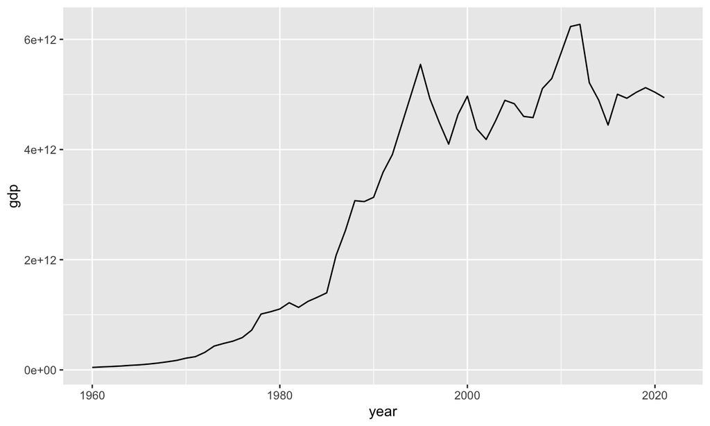

```r
df_gdp %>% filter(country == "Japan") %>%
  ggplot(aes(x = year, y = gdp)) + geom_line()
```

```
df_gdp %>% filter(country == "Japan") %>%
  ggplot(aes(x = year, y = gdp)) + geom_line()
```

日本を選択したときに、それに名前をつけておいて、それを使うこともできますが、名前がどんどん増えるので、それに続けて、コードを書いていく方法をとっています。

`ggplot(aes(x = year, y = gdp)) + geom_line()`

の部分が、グラフを描く部分で、「x 軸を、year、y 軸を、gdp として、それを、折線グラフで描いてください」というコードです。

Warning: Removed 1 row containing missing values

と表示されています。値がない年があることを言っています。2022年のデータがないことがわかっていますから、最初から削除してこくことも可能です。

### データの理解 Understand data

視覚化によって見えてくることがいくつもありますね。どんなことがわかりますか。気づいたこと（observation）をあげてみましょう。

コードを描くことではなく、この部分が、データサイエンスの核の部分です。気づいたことを列挙してみましょう。

### さまざまな視覚化

#### Fig 2. 各年ごとのデータの数

`summary(df_gdp)` で、データ自体は、1960年から2022年までのようですが、日本も、2022年のデータはありませんでしたから、年によって、どの程度データがあるか、調べてみます。

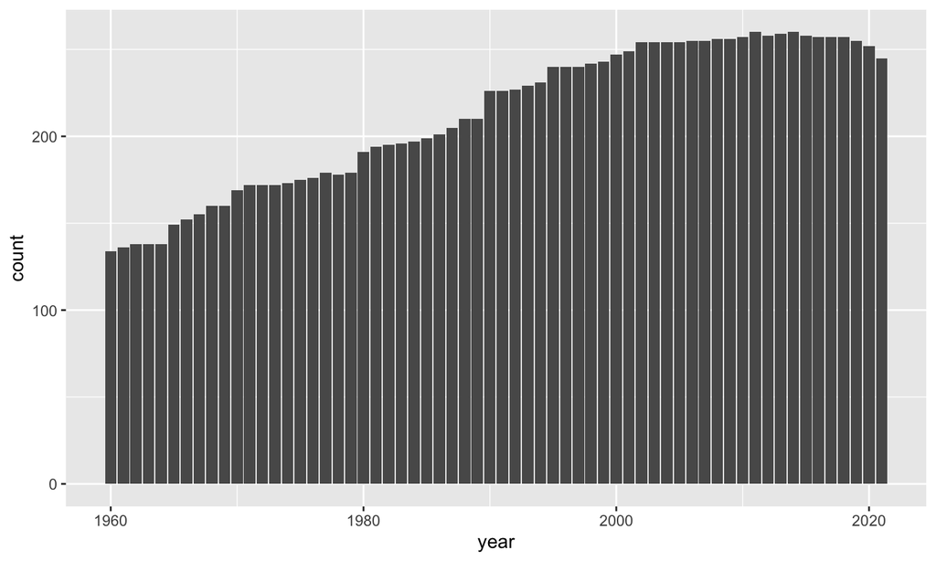

```r
df_gdp %>% drop_na(gdp) %>% ggplot(aes(x = year)) + geom_bar()
```

```
df_gdp %>% drop_na(gdp) %>% ggplot(aes(x = year)) + geom_bar()
```

バー・グラフを使いますが、`gdp` の値が、欠損値（NA: not available）のデータを削除してから、グラフを描きます。

#### 2021年のGDPの降順での表示（１）

最新の2021年のデータはすべてあるわけではなさそうですが、`gdp` の値が大きい順に並べてみましょう。

```r
df_gdp %>% filter(year == 2021) %>% drop_na(gdp) %>% arrange(desc(gdp))
```

```
##                                                  country iso2c iso3c year
## 1                                                  World    1W   WLD 2021
## 2                                            High income    XD       2021
## 3                                           OECD members    OE   OED 2021
## 4                              Post-demographic dividend    V4   PST 2021
## 5                                       IDA & IBRD total    ZT   IBT 2021
## 6                                    Low & middle income    XO   LMY 2021
## 7                                          Middle income    XP   MIC 2021
## 8                                              IBRD only    XF   IBD 2021
## 9                                    East Asia & Pacific    Z4   EAS 2021
## 10                                   Upper middle income    XT       2021
## 11                             Late-demographic dividend    V3   LTE 2021
## 12                                         North America    XU   NAC 2021
## 13                                 Europe & Central Asia    Z7   ECS 2021
## 14                                         United States    US   USA 2021
```

[output cut: 969 more lines]

#### 2021年のGDPの降順での表示（２）

最初に、World と表示され、グループや、カテゴリーのデータもあるようですから、それを、まず、削除することが必要です。`region` の列を見ると、World などは、Aggregates となっているので、そのようなものを削除すればよさそうです。数値の大きい順に並べたいので、`desc` 降順（descending order）にします。

```r
df_gdp %>% filter(year == 2021, region != "Aggregates") %>%
  drop_na(gdp) %>% arrange(desc(gdp))
```

```
##                            country iso2c iso3c year          gdp status
## 1                    United States    US   USA 2021 2.331508e+13
## 2                            China    CN   CHN 2021 1.773406e+13
## 3                            Japan    JP   JPN 2021 4.940878e+12
## 4                          Germany    DE   DEU 2021 4.259935e+12
## 5                            India    IN   IND 2021 3.176295e+12
## 6                   United Kingdom    GB   GBR 2021 3.131378e+12
## 7                           France    FR   FRA 2021 2.957880e+12
## 8                            Italy    IT   ITA 2021 2.107703e+12
## 9                           Canada    CA   CAN 2021 1.988336e+12
## 10                     Korea, Rep.    KR   KOR 2021 1.810956e+12
## 11              Russian Federation    RU   RUS 2021 1.778783e+12
## 12                          Brazil    BR   BRA 2021 1.608981e+12
## 13                       Australia    AU   AUS 2021 1.552667e+12
## 14                           Spain    ES   ESP 2021 1.427381e+12
```

[output cut: 576 more lines]

これは、グラフではありませんが、これも一つの視覚化とも考えられないことはありません。

上位７カ国は、United States, China, Japan, Germany, India, United Kingdom, France であることがわかりました。8番目は、Italy でここまでが、GDP が 2兆ドルを越している国となります。

#### Fig 3. 2021年時のGDP上位7カ国のGDP経年変化

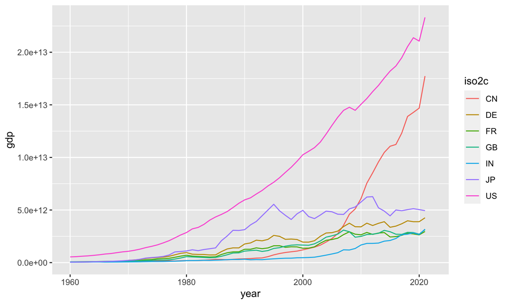

```r
df_gdp %>% filter(iso2c %in% c("US", "CN", "JP", "DE", "IN", "GB", "FR")) %>%
  ggplot(aes(x = year, y = gdp, col = iso2c)) + geom_line()
```

```
df_gdp %>% filter(iso2c %in% c("US", "CN", "JP", "DE", "IN", "GB", "FR")) %>%
  ggplot(aes(x = year, y = gdp, col = iso2c)) + geom_line()
```

ここでは、最初に、`filter` を使って、7カ国のデータを選択しています。 そのときには、`%in%` として、国名を、combine するといういみで、`c()` とひとまとめにします。数字ではなく、文字なので、引用符で囲んでいます。この場合は、single quote でも構いませんが、半角を使ってください。

このグラフからは、どのようなことがわかりますか。気づいたことを書いてみましょう。

もう少し、このようなグラフをみてみたいというような、メモも大切です。

#### Fig 4. 世界のGDP における割合（１）

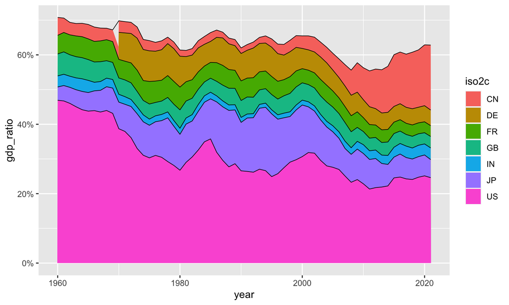

```r
df_gdp %>%
  filter(region != "Aggregates") %>% drop_na(gdp) %>%
  group_by(year) %>% mutate(gdp_ratio = gdp/sum(gdp)) %>% ungroup() %>%
  filter(iso2c %in% c("US", "CN", "JP", "DE", "IN", "GB", "FR"))  %>%
  ggplot(aes(x = year, y = gdp_ratio, fill = iso2c)) + geom_area() +
  geom_line(col = "black", position = "stack", linewidth = 0.3) +
  scale_y_continuous(labels = scales::percent_format(accuracy = 1))
```

まず、下の部分が新しいですが、ここでは、年毎にグループにして、その上で、新しい `dgp_ratio` という名前の列を追加し、その gdp の値を、gdp 合計で割っています。すなわち、世界の、GDP における割合が計算されています。

```
  group_by(year) %>% mutate(gdp_ratio = gdp/sum(gdp)) %>% ungroup() %>%
```

下の部分では、`geom_area` を使って、`fill=iso2c` により、`iso2c` ごとに、違う色を塗って、position = “stack” により、積み上げ型の、グラフを描き、境目がわかりやすいように、0.3 の太さの黒の線を描いてください。また、y 軸は、小数点以下を省いたパーセント表示に変えてください。というコードです。

```
  ggplot(aes(x = year, y = gdp_ratio, fill = iso2c)) + geom_area() +
  geom_line(col = "black", position = "stack", linewidth = 0.3) +
  scale_y_continuous(labels = scales::percent_format(accuracy = 1))
```

#### Fig 4. 世界のGDP における割合（２）

これは、上から、iso2c の アルファベットの順番になっていますが、積み上げの順序を変更することもできます。

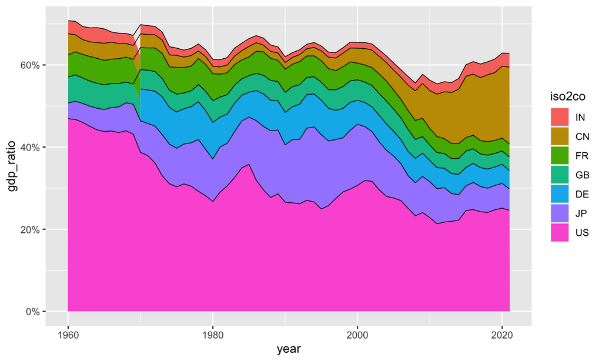

```r
df_gdp %>%
  filter(region != "Aggregates") %>% drop_na(gdp) %>%
  group_by(year) %>% mutate(gdp_ratio = gdp/sum(gdp)) %>% ungroup() %>%
  filter(iso2c %in% c("US", "CN", "JP", "DE", "IN", "GB", "FR"))  %>%
  mutate(iso2co = factor(iso2c, levels = c("IN", "CN", "FR", "GB", "DE", "JP", "US"))) %>%
  ggplot(aes(x = year, y = gdp_ratio, fill = iso2co)) + geom_area() +
  geom_line(col = "black", position = "stack", linewidth = 0.3) +
  scale_y_continuous(labels = scales::percent_format(accuracy = 1))
```

これらは、世界全体の GPT における割合です。

どのようなことがわかりますか。

主要国で、60%〜70% を占めていることがわかります。それぞれの国や、幾つかの国の影響力も、ある程度みることができるように見えます。

気づいたこと、疑問に思ったことなどを、書き出してみてください。

GDP が大きな国と、小さな国があるのはわかりますが、それは、どのように分布しているのでしょうか。

#### Fig 5. 2021年の世界の国のGDPの分布（１）

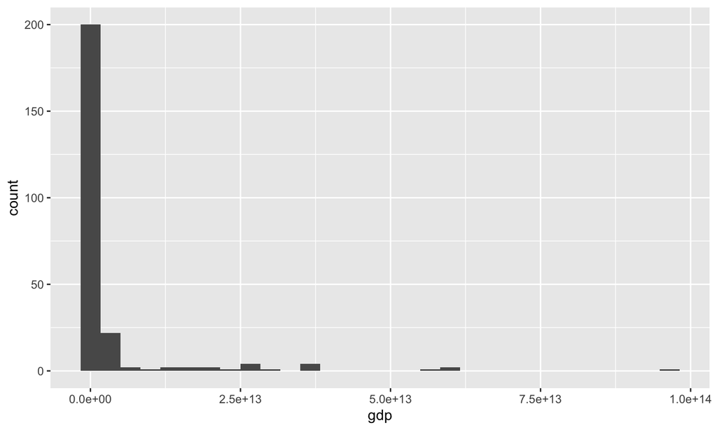

```r
df_gdp %>% drop_na(gdp) %>%
  filter(year == 2021) %>%
  ggplot(aes(gdp)) + geom_histogram()
```

小さいところに集中していることがわかりますが、`scale_x_log10()` を加え、対数軸をとってみます。

\(log10(1000) = 3\), \(log10(1000000) = 6\), \(log10(1000000000) = 9\) などになります。

#### Fig 6. 2021年の世界の国のGDPの分布（２）

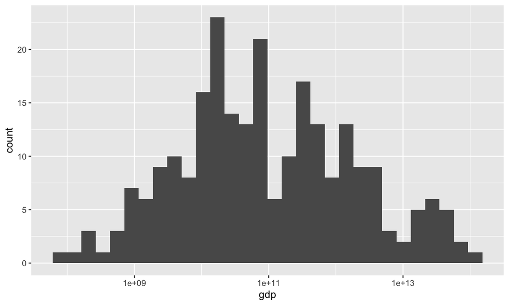

```r
df_gdp %>% drop_na(gdp) %>%
  filter(year == 2021) %>%
  ggplot(aes(gdp)) + geom_histogram() + scale_x_log10()
```

幅を変更したり、分ける個数を変更するには `binwidth = 0.5` や、`bins = 20` を、`geom_histogram()` のかっこの中に入れます。

#### Fig 7. 2021年の世界の国のGDPの分布（３）

また、密度曲線に変えるには、`geom_density` を使います。

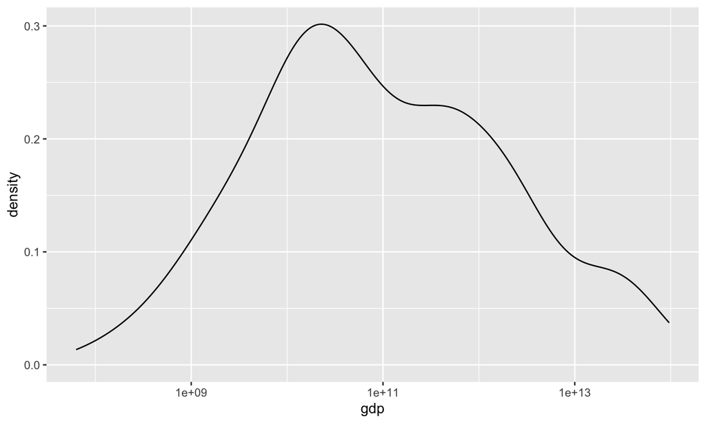

```r
df_gdp %>% drop_na(gdp) %>%
  filter(year == 2021) %>%
  ggplot(aes(gdp)) + geom_density() + scale_x_log10()
```

これは、2021年のデータですが、density の変化を見てみます。alpha の値は透明度です。

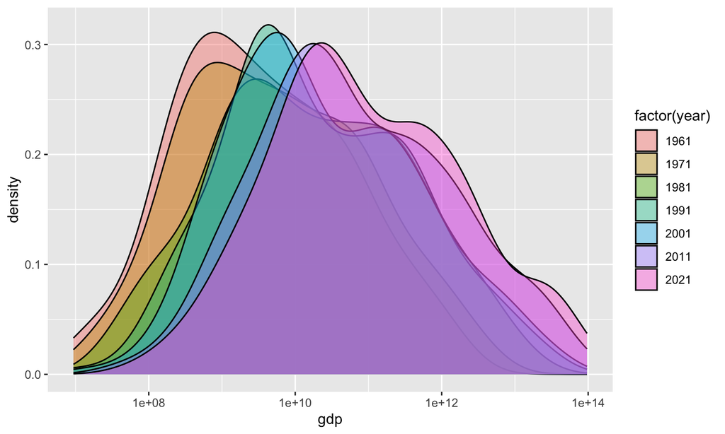

```r
df_gdp %>% drop_na(gdp) %>%
  filter(year %in% c(1961, 1971, 1981, 1991, 2001, 2011, 2021)) %>%
  ggplot(aes(gdp, fill = factor(year))) + geom_density(alpha = 0.4) + scale_x_log10()
```

少しみにくいので、分けてみます。

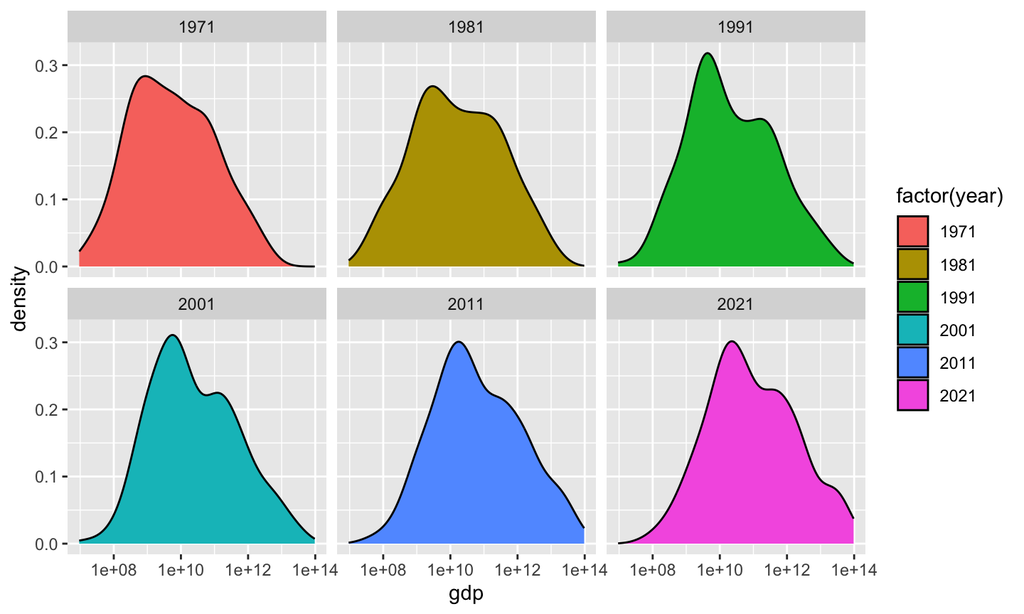

```r
df_gdp %>% drop_na(gdp) %>%
  filter(year %in% c(1971, 1981, 1991, 2001, 2011, 2021)) %>%
  ggplot(aes(gdp, fill = factor(year))) +
  geom_density() + scale_x_log10() + facet_wrap(~year)
```

#### Fig 10. 地域ごとの GDP の分布

いくつかのグループごとに分布をみてみることも可能です。それには、Boxplot が有効です。

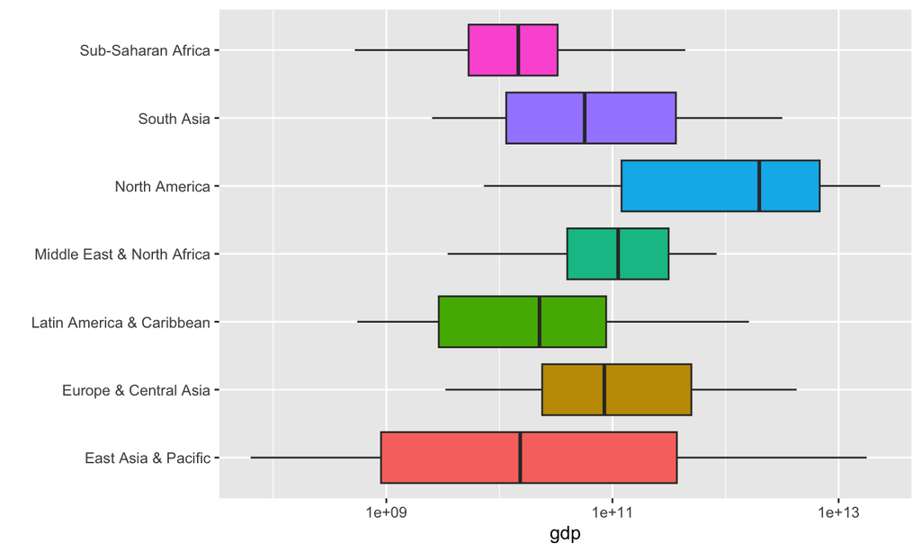

```r
df_gdp %>% drop_na(gdp) %>% filter(region != "Aggregates") %>%
  drop_na(region) %>% filter(year %in% c(2021)) %>%
  ggplot(aes(gdp, region, fill = region)) +
  geom_boxplot() + scale_x_log10() + labs(y = "") +
  theme(legend.position = "none")
```

#### Fig 11. 収入の多寡による分類ごとの GDP 分布

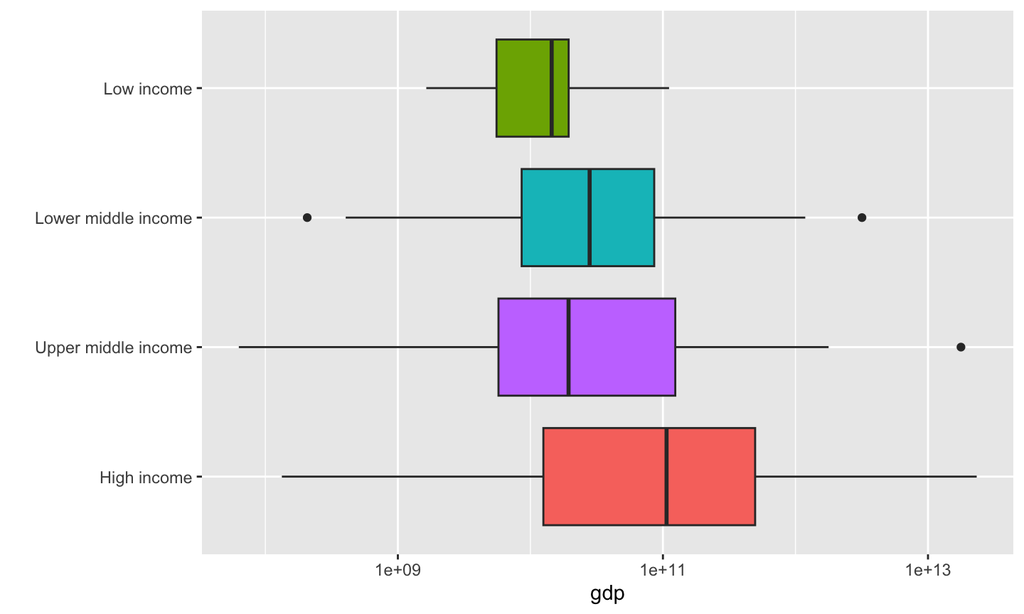

```r
df_gdp %>% drop_na(gdp) %>% filter(region != "Aggregates") %>%
  drop_na(income) %>% filter(year %in% c(2021)) %>%
  mutate(level = factor(income, c("High income", "Upper middle income", "Lower middle income", "Low income"))) %>%
  ggplot(aes(gdp, level, fill = income)) +
  geom_boxplot() + scale_x_log10() + labs(y = "") +
  theme(legend.position = "none")
```

これからも、いろいろなことがわかりますね。

#### 世界地図の準備

地図で、国の income level をみてみましょう。

```r
library(maps)
map_world <- map_data('world')
map_gdp <- map_world %>%
  mutate(iso2c = iso.alpha(region, n=2)) %>%
  mutate(map_region = region) %>% select(-region) %>%
  left_join(df_gdp, by = "iso2c")
head(map_gdp)
```

```
##        long    lat group order subregion iso2c map_region country iso3c year
## 1 -69.89912 12.452     1     1      <NA>    AW      Aruba   Aruba   ABW 1999
## 2 -69.89912 12.452     1     1      <NA>    AW      Aruba   Aruba   ABW 1998
## 3 -69.89912 12.452     1     1      <NA>    AW      Aruba   Aruba   ABW 2001
## 4 -69.89912 12.452     1     1      <NA>    AW      Aruba   Aruba   ABW 2000
## 5 -69.89912 12.452     1     1      <NA>    AW      Aruba   Aruba   ABW 1995
## 6 -69.89912 12.452     1     1      <NA>    AW      Aruba   Aruba   ABW 1994
##          gdp status lastupdated                    region    capital longitude
## 1 1722905028         2023-05-10 Latin America & Caribbean Oranjestad  -70.0167
## 2 1665363128         2023-05-10 Latin America & Caribbean Oranjestad  -70.0167
## 3 1896648045         2023-05-10 Latin America & Caribbean Oranjestad  -70.0167
## 4 1873184358         2023-05-10 Latin America & Caribbean Oranjestad  -70.0167
## 5 1320670391         2023-05-10 Latin America & Caribbean Oranjestad  -70.0167
## 6 1245810056         2023-05-10 Latin America & Caribbean Oranjestad  -70.0167
##   latitude      income        lending
## 1  12.5167 High income Not classified
## 2  12.5167 High income Not classified
## 3  12.5167 High income Not classified
## 4  12.5167 High income Not classified
## 5  12.5167 High income Not classified
## 6  12.5167 High income Not classified
```

#### Fig 12. Income Level による色分け地図

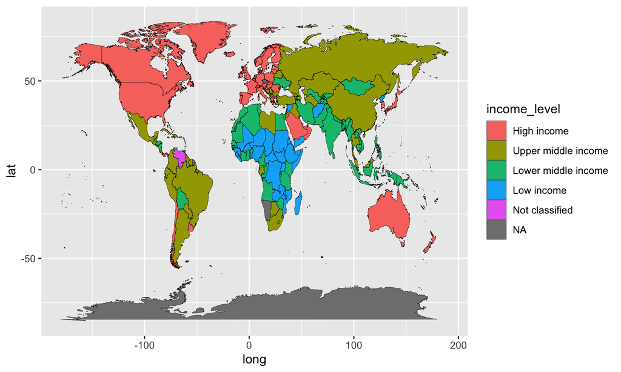

```r
map_gdp %>% mutate(income_level = factor(income, levels = c("High income", "Upper middle income", "Lower middle income", "Low income", "Not classified", NA))) %>%
  ggplot() +
  geom_map(aes(long, lat, map_id = map_region, fill = income_level), map = map_world, col = "black", size = 0.1)
```

#### Fig 13. GDP による色分け地図

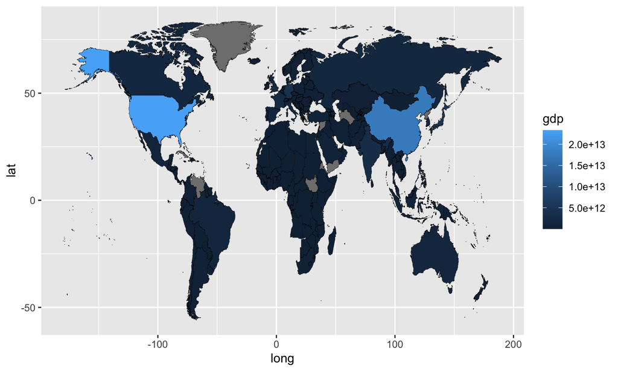

```r
map_gdp %>% mutate(income_level = factor(income, levels = c("High income", "Upper middle income", "Lower middle income", "Low income", "Not classified", NA))) %>%
  filter(year == 2021) %>%
  ggplot() +
  geom_map(aes(x=long, y=lat, map_id = map_region, fill = gdp), map = map_world, col = "black", size = 0.1)
```

## プロジェクト

他のデータで、同様のことをしてみましょう。

1. 最初に、`gdp = "NY.GDP.MKTP.CD"` としましたが、GNI per capita, Atlas method (current US$): NY.GNP.PCAP.CD に変えてみましょう。

```r
df_gnppcap <- WDI(country = "all",
              indicator = c(gnppcap = "NY.GNP.PCAP.CD"),
              extra = TRUE)
```

1. [World Development Indicators](https://datatopics.worldbank.org/world-development-indicators/) のサイトの下にある、Data Themes（テーマ）から自分が調べたいテーマを選び、そのテーマから、データコードを取得して、同様の分析をしてみてください。データがあまりない場合もありますので、ある程度データが多いものを選択することをお勧めします。

## まとめ

今回は、経済指標である、GDP を使いました。データサイエンスについて少しずつ、学んでいきます。

コードの説明は、簡単にしかしていませんから、理解するのは難しいと思いますが、いくつかのことは、ご理解いただけると思います。

- それほど、長くはない、コードで、データを見ていく。R は対話型（interactive）のプログラミング言語と言われています。
- コードに続けて、結果が表示されるので、コードと出力の対応が見やすい。また、コメントや説明も併記することができる。これは、RMarkdown という形式の中で、コードを書いていることによるものです。RMarkdown は、再現性（reproducibility）と、プログラム・コードの内容をコンピュータにわかるようにでなく、人間にもわかるように記述する（Literate Programming）を実現しています。
- 視覚化（Visualization）によって、わかることが色々とある。また、視覚化の方法もたくさんあり、いろいろな見方をすることで、データについての理解が深まっていく。
- 視覚化を通して、データを理解すること、問いを持ち、他の視覚化などを用いて、さらに、理解を深めることがたいせつ。
- 理解したことを元にして、さらに、そのデータ、または、他のデータを使って、新たな発見をしていく。

統計的な指標も用いますが、それらによって、新しい知識を生み出すとも表現しますが、そのような営み全体が、データサイエンスの核をなす部分だと思います。